# Sierra Amphibians

Sachiko Lamen

1/19/2022

```r
knitr::opts_chunk$set(echo = TRUE, message = FALSE, warning = FALSE)
library(tidyverse)
library(here)
library(patchwork)
library(cowplot)
library(readxl)
library(reprex)
```

## **Introduction**

This report explores data collected on endangered Mountain Yellow-legged frogs (Rana muscosa) by the Sierra Lakes Inventory Project (SLIP) from 1995-2002. Abundance of yellow-legged frogs was compared amongst life stage: adult, sub-adult, and tadpole. The life stage “egg mass” was not included for the purpose of this analysis.

## **Analysis**

This analysis filters the data for counts of Moutain Yellow-legged frogs by life stage (Adult, Sub-adult, and Tadpole) from 1995 - 2002 across Sierra Nevada Region. The second part of this analysis filters for the top five lakes with the highest total counts (combined adult and subadult) of yellow-legged frogs. Results are presented in a combined visualization.

```r
# Read in data
sierra_amph <- read_xlsx(here("data", "sierra_amphibians.xlsx"))

# Create subset that filters for yellow-legged frogs: adult, sub-adult, and tadpole,and get total counts
yellow_frog_total <- sierra_amph %>%
  separate(survey_date, c("Year")) %>%
  group_by(amphibian_life_stage, Year) %>%
  filter(amphibian_life_stage != "EggMass",
         amphibian_species == "RAMU") %>%
  summarize(count = n())

# Create column graph of above subset. Do not include in knitted document.
p1 <- ggplot(data = yellow_frog_total, aes(x = Year, y = count, fill = factor(amphibian_life_stage))) +
  geom_col(stat = "identity", position = "dodge", color = "black") +
  labs(x = "Year",
       y = "Count",
       title = "Total mountain yellow-legged frog count") +
  scale_fill_manual("Life Stage", values = c("darkgreen", "green", "yellow")) +
  theme_minimal()
```

```r
# Create subset of top five lakes with highest count of adult and subadult yellow-legged frogs
top_5_lakes <- sierra_amph %>%
  filter(amphibian_species =="RAMU", amphibian_life_stage %in% c("Adult", "SubAdult")) %>%
  filter(amphibian_location == "in lake") %>%
  select(lake_id) %>%
  count(lake_id) %>%
  slice_max(order_by = n, n = 5) %>%
  mutate(lake_id = paste("Lake", lake_id, sep = ' ')) %>%
  mutate(lake_id = fct_reorder(lake_id, n))

# Create column graph of above subset. Do not include in knitted document
p2 <- ggplot(data = top_5_lakes, aes(x = n, y = lake_id)) +
  geom_col(fill = "lightblue") +
  labs(x = "Total Counts",
       y = "Lake ID",
       title = "Top 5 lakes with total combined adult and subadult \n counts of Rana muscosa (1995-2002)") +
  theme_minimal() +
  theme(panel.grid.major = element_blank())
```

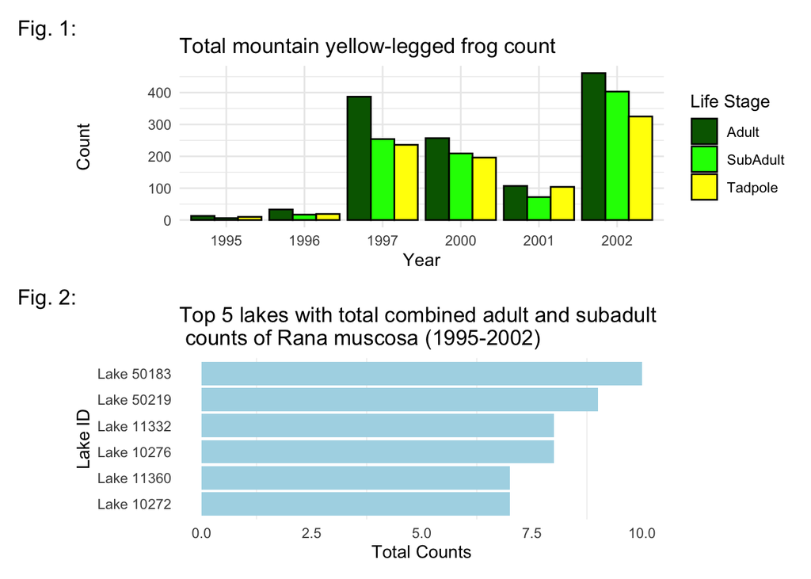

```r
# Combine previously created graphs into one compound figure using `patchwork`
patchwork <- p1 / p2

patchwork +
  plot_annotation(tag_levels = c('1'), tag_prefix = 'Fig. ',
                            tag_sep = '.', tag_suffix = ':')
```

## **Summary**

Total counts of endangered Mountain Yellow-Legged Frogs have increased since 1995, with the highest numbers observed in 2002, the last year of this study. Figure 2 shows that there are relatively few frogs in each lake, as the top five lakes only contained between 7 - 10 frogs.

## **Citation**

*Knapp, R.A., C. Pavelka, E.E. Hegeman, and T.C. Smith. 2020. The Sierra Lakes Inventory Project: Non-Native fish and community composition of lakes and ponds in the Sierra Nevada, California ver 2. Environmental Data Initiative. https://doi.org/10.6073/pasta/d835832d7fd00d9e4466e44eea87fab3*